# readme

Wagner Pinheiro

20 de junho de 2015

# Exploratory Data Analysis - Course Project 2

```r
# load data
source('loadLib.R')
readData()
```

```
## [1] "Loading Data..."
## [1] "Data Loaded."
```

## Question 1

> Q: Have total emissions from PM2.5 decreased in the United States from 1999 to 2008? Using the base plotting system, make a plot showing the total PM2.5 emission from all sources for each of the years 1999, 2002, 2005, and 2008.

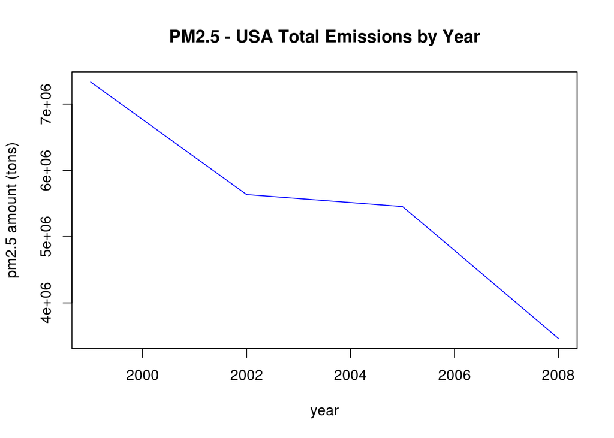

```r
makePlot1()
```

A: Yes, total emissions decreased

## Question 2

> Q: Have total emissions from PM2.5 decreased in the Baltimore City, Maryland (fips == 24510) from 1999 to 2008? Use the base plotting system to make a plot answering this question.

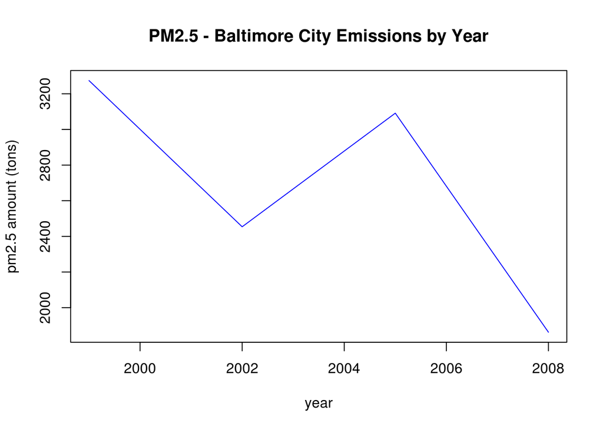

```r
makePlot2()
```

A: Yes, emissions from PM2.5 decreased in the Baltimore City, Maryland.

## Question 3

> Q: Of the four types of sources indicated by the type (point, nonpoint, onroad, nonroad) variable, which of these four sources have seen decreases in emissions from 1999–2008 for Baltimore City? Which have seen increases in emissions from 1999–2008? Use the ggplot2 plotting system to make a plot answer this question.

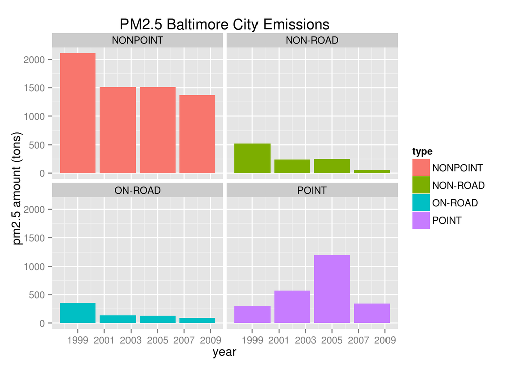

```r
makePlot3()
```

A: ‘Nonpoint’, ‘onroad’, ‘nonroad’ type’s decreases in emissions from 1999-2008. Only ‘point’ type emissions have increased in the same period

## Question 4

> Q: Across the United States, how have emissions from coal combustion-related sources changed from 1999–2008?

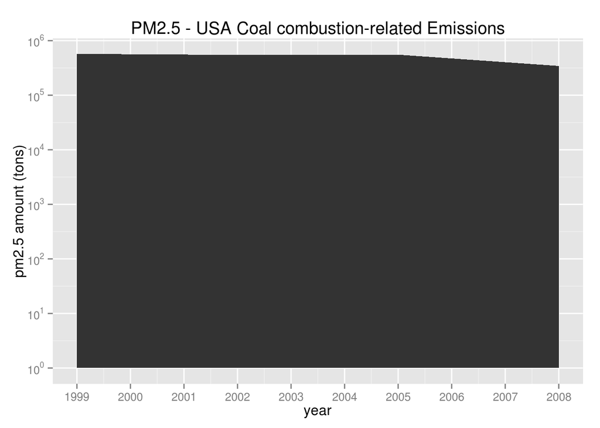

```r
makePlot4()
```

A: Emissions from coal combustion drecreased at low rates over time.

## Question 5

> Q: How have emissions from motor vehicle sources changed from 1999–2008 in Baltimore City?

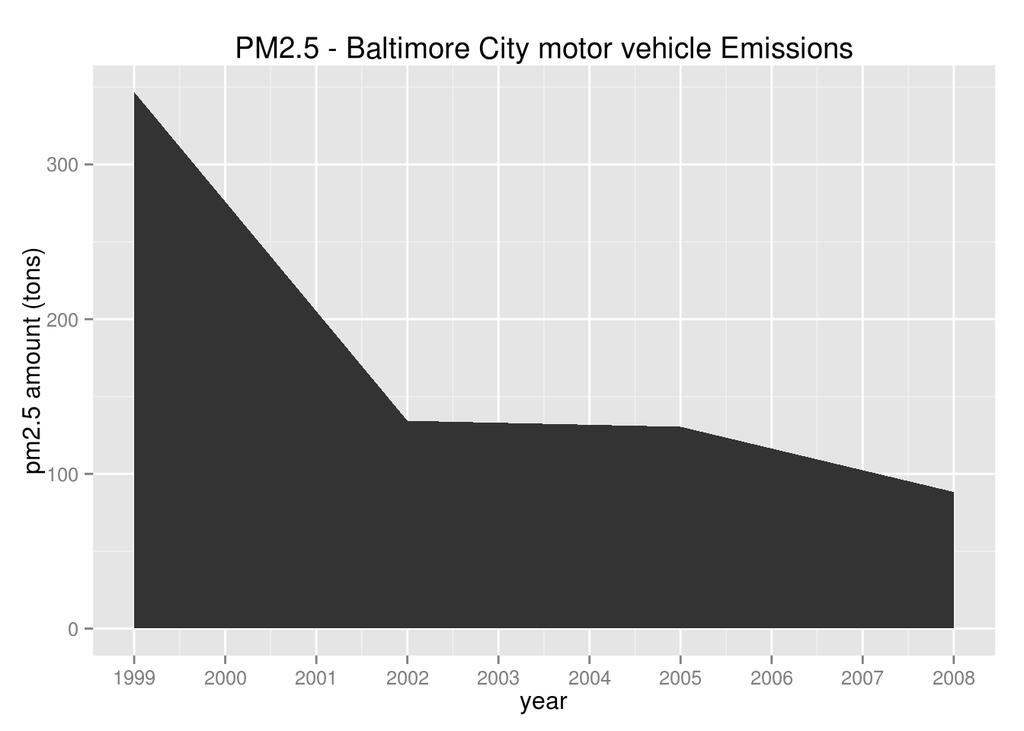

```r
makePlot5()
```

A: Emissions declined at high rates between 1999-2002, and it is in continuous decline.

## Question 6

> Q: Compare emissions from motor vehicle sources in Baltimore City with emissions from motor vehicle sources in Los Angeles County, California (fips == 06037). Which city has seen greater changes over time in motor vehicle emissions?

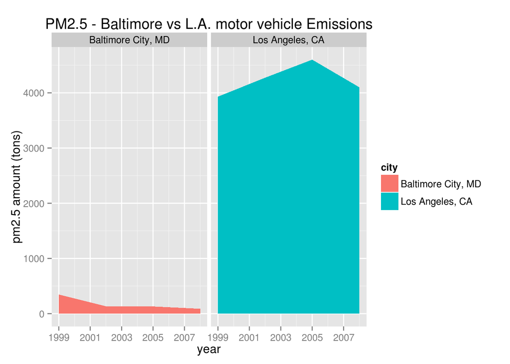

```r
makePlot6()
```

A: There is a long road to L.A. decreased emissions.